# Battle of Neighborhoods

## The Battle of Neighborhoods: Define and Introduce business probem

### Introduction and background

The purpose of this proejct is to find the most similar neigborhood of lifestyle in Totonto Canada. This is helping me to find how to make decision on selecting best neigborhood to match your current living environment. Let's talk about story background first, I am now living in manhattan ,new york which the one of the most famous cities in the world and the the neigborhood name is Chelsea. I am very satisfied with current location. Two week ago , a new work offer from toronto sent to me with better benefits and opportunity . So i accept this offer and preapre move to toronto .

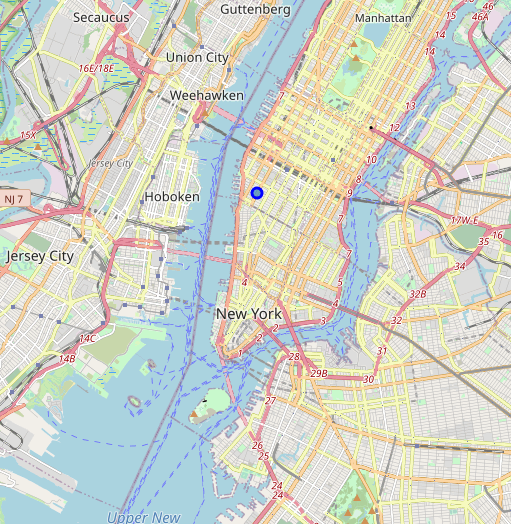

### Problem Description

The main propose of this project , it's to find a same or best neigborhood in city of toronto when i am shifting there. So for detail,i am currently live in chelsea , manhattan.I like local coffee shop,art gallery and of course ice cream shop and so many muti-culture restaurants. I want to keep my life style in toronto. So i will use python to discover.

### The New location

Toronto is the most largest city in Canada ,aslo it's one the most important cities within north america. i will use all toronto neigborhoods to match my current .But i will more foucs on downtown , midtown areas, becasue it's not very far from my new working place which is in downtown.

### Success Criteria

The success criteria of this project is a good recommendation of the neigborhhod choice in Toronto to live . and the lifestyle both in chelsea and toront should be as closer as much.